```python
import seaborn as sb #importing necessary packages for working with the data
import pandas as pd
import numpy as np
import matplotlib as mpl
import matplotlib.pyplot as plt
```

```python
pd.set_option("display.max_rows",100)
```

# Step 1: Importing Data

```python
data = pd.read_csv('AB_NYC_2019.csv') # import data from csv to python using pandas
```

# Step 2: Cleaning Data (Question 1)

Missing names for listing and name of host.

Replaced with listing id and host id respectively.

Missing values for reviews per month because 0 is not available. Thus replaced with 0.

```python
data.info()
```

```
<class 'pandas.core.frame.DataFrame'>
RangeIndex: 48895 entries, 0 to 48894
Data columns (total 16 columns):
 #   Column                          Non-Null Count  Dtype
---  ------                          --------------  -----
 0   id                              48895 non-null  int64
 1   name                            48879 non-null  object
 2   host_id                         48895 non-null  int64
 3   host_name                       48874 non-null  object
 4   neighbourhood_group             48895 non-null  object
 5   neighbourhood                   48895 non-null  object
 6   latitude                        48895 non-null  float64
 7   longitude                       48895 non-null  float64
 8   room_type                       48895 non-null  object
 9   price                           48895 non-null  int64
 10  minimum_nights                  48895 non-null  int64
 11  number_of_reviews               48895 non-null  int64
 12  last_review                     38843 non-null  object
 13  reviews_per_month               38843 non-null  float64
 14  calculated_host_listings_count  48895 non-null  int64
 15  availability_365                48895 non-null  int64
dtypes: float64(3), int64(7), object(6)
memory usage: 6.0+ MB
```

```python
ndata = data.isnull()
```

```python
for i,j in enumerate(ndata['name']): #replacing null name with id
    if(j==True):
        data.loc[i,'name'] = str(data.loc[i,'id'])

for i,j in enumerate(ndata['host_name']): #replacing null host name with host id
    if(j==True):
        data.loc[i,'host_name'] = str(data.loc[i,'host_id'])
for i,j in enumerate(ndata['reviews_per_month']): # replacing null reviews per month with 0
    if(j==True):
        data.loc[i,'reviews_per_month'] = 0
```

```python
data.info()
```

```
<class 'pandas.core.frame.DataFrame'>
RangeIndex: 48895 entries, 0 to 48894
Data columns (total 16 columns):
 #   Column                          Non-Null Count  Dtype
---  ------                          --------------  -----
 0   id                              48895 non-null  int64
 1   name                            48895 non-null  object
 2   host_id                         48895 non-null  int64
 3   host_name                       48895 non-null  object
 4   neighbourhood_group             48895 non-null  object
 5   neighbourhood                   48895 non-null  object
 6   latitude                        48895 non-null  float64
 7   longitude                       48895 non-null  float64
 8   room_type                       48895 non-null  object
 9   price                           48895 non-null  int64
 10  minimum_nights                  48895 non-null  int64
 11  number_of_reviews               48895 non-null  int64
 12  last_review                     38843 non-null  object
 13  reviews_per_month               48895 non-null  float64
 14  calculated_host_listings_count  48895 non-null  int64
 15  availability_365                48895 non-null  int64
dtypes: float64(3), int64(7), object(6)
memory usage: 6.0+ MB
```

# Step 3: Neighborhood Pricing Trends (Question 2)

```python
ntc = dict() #total price of neighbourhood and number of listings in that neighbourhood [totalprice, count, mean,neighbourhood group]
for i,j in enumerate(data['neighbourhood']):
    if not(j in  ntc):
        ntc[j] = [0,0,0,0]
    ntc[j] = [ntc[j][0]+data.loc[i,'price'],ntc[j][1]+1,0,data.loc[i,'neighbourhood_group']]
```

```python
for i in ntc:
    ntc[i] = [ntc[i][0],ntc[i][1],float(ntc[i][0])/float(ntc[i][1]),ntc[i][3]]
```

```python
neighbourhooddata=pd.DataFrame(ntc.values(), index=ntc.keys())
neighbourhooddata.columns = ["Total Price", "# of Listings", "Mean Price", "Neighbourhood Group"]
```

```python
sortedbymean=neighbourhooddata[neighbourhooddata['# of Listings'] > 5].sort_values(by=['Mean Price'])
sortedbymean
#sort by mean price neighbourhoods with more than 5 listings
```

|  | Total Price | # of Listings | Mean Price | Neighbourhood Group |
| --- | --- | --- | --- | --- |
| Bull's Head | 284 | 6 | 47.333333 | Staten Island |
| Hunts Point | 909 | 18 | 50.500000 | Bronx |
| Tremont | 567 | 11 | 51.545455 | Bronx |
| Soundview | 802 | 15 | 53.466667 | Bronx |
| Bronxdale | 1085 | 19 | 57.105263 | Bronx |
| ... | ... | ... | ... | ... |
| Flatiron District | 27354 | 80 | 341.925000 | Manhattan |
| Battery Park City | 25729 | 70 | 367.557143 | Manhattan |
| Riverdale | 4863 | 11 | 442.090909 | Bronx |
| Sea Gate | 3415 | 7 | 487.857143 | Brooklyn |
| Tribeca | 86843 | 177 | 490.638418 | Manhattan |

190 rows × 4 columns

The top 5 most expensive neighborhoods are Tribeca, Sea Gate, Riverdale, Battery Park City, and Flatiron District

The top 5 least expensive neighborhoods are Bronxdale, Soundview, Tremont, Hunts Point, and Bull's Head

```python
ngm = dict() # mean pricing per neighbourhood_group
for i,j in enumerate(data['neighbourhood_group']):
    if not(j in  ngm):
        ngm[j] = [0,0,0]
    ngm[j] = [ngm[j][0]+data.loc[i,'price'],ngm[j][1]+1,0]
```

```
<BarContainer object of 5 artists>
```

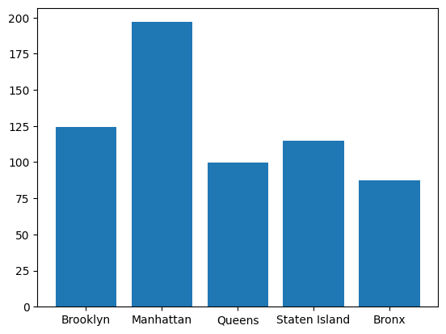

```python
for i in ngm:
    ngm[i] = [ngm[i][0],ngm[i][1],float(ngm[i][0])/ngm[i][1]]
plt.bar(ngm.keys(),[i[2] for i in ngm.values()])
```

Highest Mean Price of Listing is in Manhattan, while lowest mean price of listing is in the Bronx

# Step 4: Pearson Analysis (Question 3)

Selecting Features: Latitude, Longitude, Price, Reviews Per Month, Availability_365

```python
def pearson(a,b): # function for calculating pearson
    mean_a = sum(a)/float(len(a))
    mean_b = sum(b)/float(len(b))
    cov = sum([(i-mean_a)*(j-mean_b)for i,j in zip(a,b)])
    stda = sum([(i-mean_a)**2 for i in a])**0.5
    stdb = sum([(j-mean_b)**2 for j in b])**0.5
    return cov/(stda*stdb)
```

```
[[1.0, 0.08478836838914387, 0.033938668232625535, -0.01875772712399139, -0.010983458290207526], [0.08478836838914387, 1.0000000000000002, -0.15001926996895382, 0.13851616595337943, 0.08273074786279411], [0.033938668232625535, -0.15001926996895382, 0.9999999999999998, -0.05056409232837583, 0.08182882…
[0.16373167028258948, 'reviews_per_month', 'availability_365']
[-0.15001926996895382, 'longitude', 'price']
```

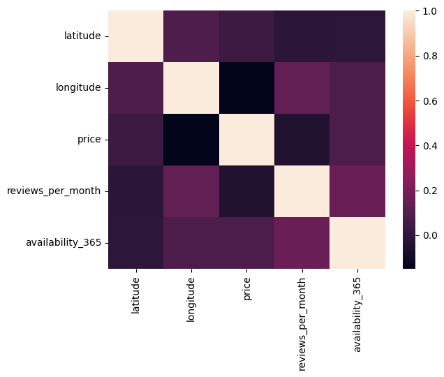

```python
features = ["latitude","longitude","price","reviews_per_month","availability_365"]
pearsonmat = []
max=[-10,"",""]
min=[10,"",""]
for i in features: # finding pearson correlations for each pair of features
    pearsonrow = []
    for j in features:
        p =pearson(data[i],data[j])
        pearsonrow.append(p)
        if i!=j:
            max = [p,i,j] if p> max[0] else max # maximum and minimum correlations
            min = [p,i,j] if p< min[0] else min

    pearsonmat.append(pearsonrow)
print(pearsonmat)
print(max)
print(min)
sb.heatmap(pearsonmat,xticklabels=features,yticklabels=features) # mapping correlation onto a heat map
```

Largest correlation is between reviews per month and availability 365, at 0.1637

Largest negative correlation is between longitude and price at -0.15

# Step 5 Coordinate Trends (Question 4)

Mapping neighbourhood group of listings and pricing of listings using color

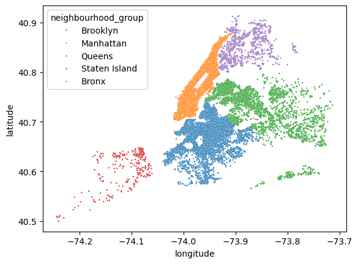

```python
sb.scatterplot(data = data,x="longitude",y="latitude",hue='neighbourhood_group',s=3)
#color map of the listings in each neghbourhood_group
```

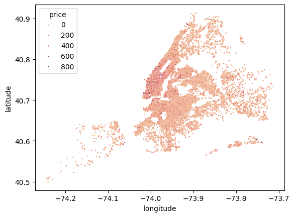

```python
under1k=data[data['price'] < 1000]
sb.scatterplot(data = under1k,x="longitude",y="latitude",hue='price',palette='flare',s=3)
```

We see that the bottom left side of manhattan is the most expensive, and there is a gradient outwards from there

# Step 6: Word Cloud (Question 5)

Word cloud of words used in Airbnb names

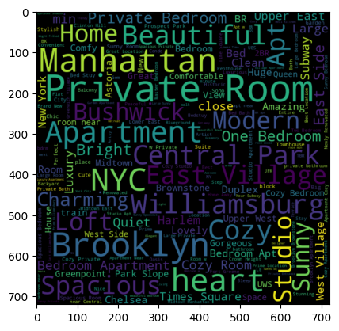

```python
from wordcloud import WordCloud, STOPWORDS, ImageColorGenerator
text = ""
for name in data["name"]:
    text = text+" " + name
wordcloud = WordCloud(width=720, height=720).generate(text)
plt.imshow(wordcloud, interpolation='bilinear')
```

# Step 7: Busiest Areas (Question 6)

Finding the areas with the busiest hosts which is defined as having a high number of listings.

```python
nhl = dict() #total price of neighbourhood and number of listings in that neighbourhood [totalprice, count, mean,neighbourhood group]
for i,j in enumerate(data['neighbourhood']):
    if not(j in  nhl):
        nhl[j] = [0,0,0,0]
    nhl[j] = [nhl[j][0]+data.loc[i,'calculated_host_listings_count'],nhl[j][1]+1,0,data.loc[i,'neighbourhood_group']]
```

```python
for i in nhl: # Finding mean number of listings of each host in a neighbourhood
    nhl[i] = [nhl[i][0],ntc[i][1],float(nhl[i][0])/float(nhl[i][1]),nhl[i][3]]

nhldataframe=pd.DataFrame(nhl.values(), index=nhl.keys())
nhldataframe.columns = ["Total Number of Listings", "# of Hosts", "Mean Listings", "Neighbourhood Group"]
```

```python
nhldataframe[nhldataframe["# of Hosts"] > 5].sort_values(by="Mean Listings")
```

|  | Total Number of Listings | # of Hosts | Mean Listings | Neighbourhood Group |
| --- | --- | --- | --- | --- |
| Rosebank | 7 | 7 | 1.000000 | Staten Island |
| Shore Acres | 7 | 7 | 1.000000 | Staten Island |
| Mariners Harbor | 8 | 8 | 1.000000 | Staten Island |
| Melrose | 10 | 10 | 1.000000 | Bronx |
| Grymes Hill | 7 | 7 | 1.000000 | Staten Island |
| ... | ... | ... | ... | ... |
| Woodside | 4554 | 235 | 19.378723 | Queens |
| Tribeca | 7606 | 177 | 42.971751 | Manhattan |
| Murray Hill | 26125 | 485 | 53.865979 | Manhattan |
| Theater District | 18704 | 288 | 64.944444 | Manhattan |
| Financial District | 85454 | 744 | 114.857527 | Manhattan |

190 rows × 4 columns

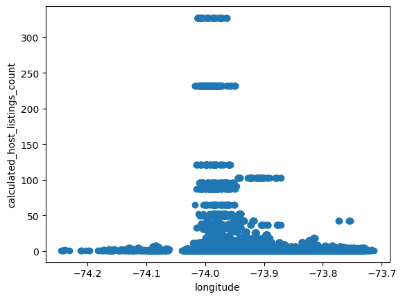

```python
plt.scatter(data['longitude'],data['calculated_host_listings_count'])
plt.xlabel('longitude')
plt.ylabel('calculated_host_listings_count')
```

We see above that near the center in longitude is where hosts are the busiest.

```
pearson correlation:0.057471688368065814
```

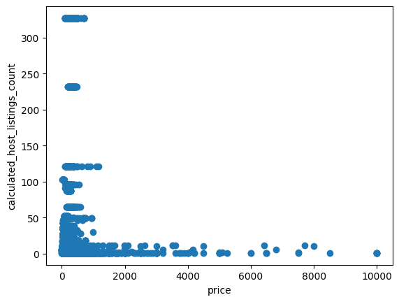

```python
plt.scatter(data['price'],data['calculated_host_listings_count'])
print("pearson correlation:" + str(pearson(data['price'],data['calculated_host_listings_count'])))
plt.xlabel('price')
plt.ylabel('calculated_host_listings_count')
```

We see above that hosts with a lot of listings are more likely to be at the bottom part of the price range.

```
pearson correlation: -0.07237606054175609
```

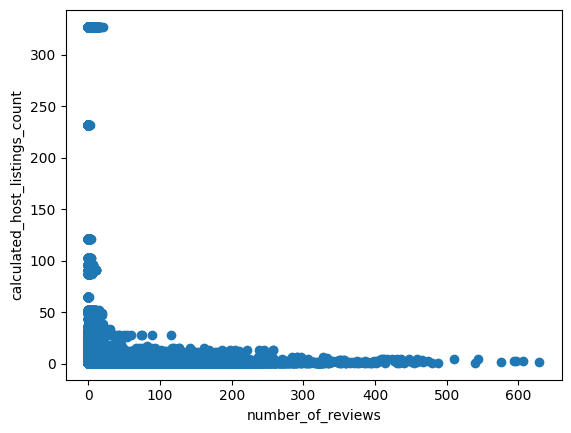

```python
plt.scatter(data['number_of_reviews'],data['calculated_host_listings_count'])
print("pearson correlation: " + str(pearson(data['number_of_reviews'],data['calculated_host_listings_count'])))
plt.xlabel('number_of_reviews')
plt.ylabel('calculated_host_listings_count')
```

We see above that hosts with a lot of listings don't have that many reviews for each of their listings

```
pearson correlation: 0.2257013721911263
```

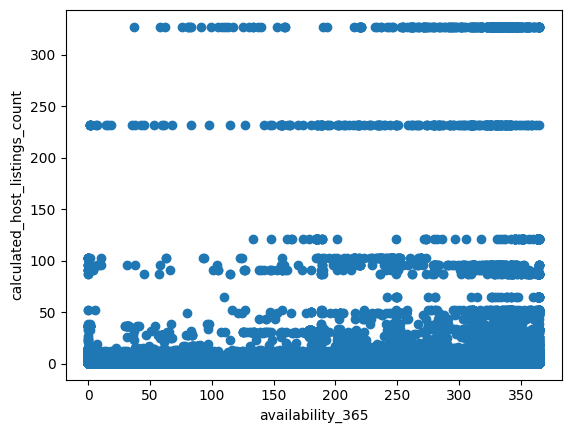

```python
plt.scatter(data['availability_365'],data['calculated_host_listings_count'])
print("pearson correlation: " + str(pearson(data['availability_365'],data['calculated_host_listings_count'])))
plt.xlabel('availability_365')
plt.ylabel('calculated_host_listings_count')
```

Through the pearson correlation of 0.226, we may conclude that the longer the availability, the more listings the host has.

From the above graphs we can conclude that the hosts with a lot of listings are at the bottom of the price range. We can also conclude that hosts with a lot of listings have a longitude that is at the center of manhattan. The financial district has a longitude of -74.01, which is near the center of manhattan and also has a mean price per listing of 225.50 which is near the bottom of the price range. This is why the financial district has the busiest hosts.

# Step 8: Interesting Plots (Question 7)

```
pearson correlation: 0.16373167028258948
```

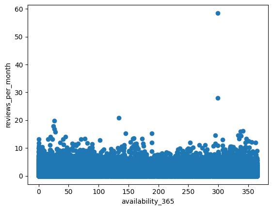

```python
print("pearson correlation: " + str(pearson(data['availability_365'],data['reviews_per_month'])))
plt.scatter(data['availability_365'],data['reviews_per_month'])
plt.xlabel('availability_365')
plt.ylabel('reviews_per_month')
```

The above plot is that of reviews per month vs availability. There is a pearson correlation of 0.163, however it is interesting that this correlation isn't stronger. One would think that the longer the availability, the more reviews it should have due to more bookings.

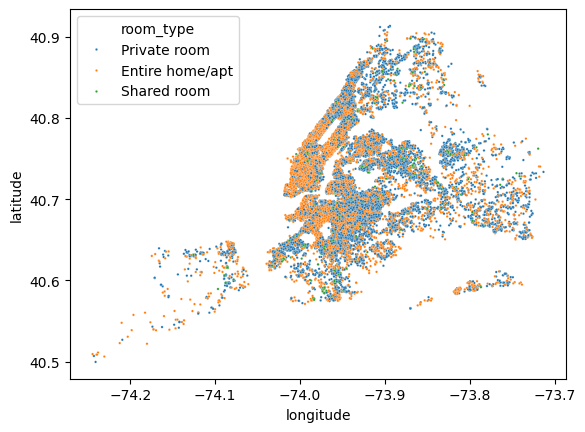

```python
sb.scatterplot(data = data,x="longitude",y="latitude",hue='room_type',s=3)
#color map of the room type
```

This is a color map of room type for each listing. We see that in Manhattan, most rooms are Entire home/apt, whereas as you move further out from manhattan, private rooms begin taking over.